# Sesion 1 Introducción

José Luis Manzanares Rivera

2021-01-10T21:13:14-05:00

```r
library(tidyverse)
```

#### Programa: Maestría en Desarrollo Regional.

##### **Semestre:** 1-2021

##### **Horas:** 15.

##### **Organización por sesiones:** 5 Sesiones, 3 horas por sesión.

##### **Curso-intersemestral:** Herramientas para Análisis estadístico: Implementación en R markdown.

### Presentación del curso.

El curso está diseñado para estudiar el uso de herramientas de análisis de datos en un entorno replicable con base en R markdown.

La orientación empírica se enfoca en la evaluación de indicadores a escaka regional en México.

**Pre-requisitos**. Conocimientos y habilidades necesarias: Es deseable contar con conocimientos previos de estadística básica y matemáticas básicas. Se require capacidad analítica y habilidades para el manejo de software.

**Competencias a desarrollar:** Análisis cuantitativo, Trabajo colaborativo.

**Objetivo(s) general(es) de la asignatura:** Dotar al alumno de Herramientas para llevar acabo manejo de datos bajo procesos de análisis replicable

El curso intersemestral da soporte a la formación en métodos cuantitativos para las materias de estadistica, Economía regional y Técnicas de análisis regional durante el programa.

**Cobertura de la asignatura:** Cubre las bases sobre la aplicación de software estadístico. Conocer este potencial permitirá a los alumnos aprovechar de forma efectiva los conocimientos que ofrece este posgrado en cuanto a la realización de análisis estadístico así como dotarlos de capacidades para desarrollar sus proyectos de investigación. Se consideran herramientas de análisis basadas en software open source.

**Requerimientos:** Laptop, R, R-studio instalado.Este progrma tiene una licencia de acceso libre. **R** Es el software que aprenderemos a utilizar para esta clase.

**Criterios de evaluación:**

- Participación colaborativa.
- Realización de ejercicios por sesión.
- Lecturas y análisis de datos extra clase.

### Programa

**Estructura del curso** [Temas](https://drive.google.com/file/d/1MD3epVmJq5pO5QssWRxEph3aEsJ_cAXB/view?usp=sharing)

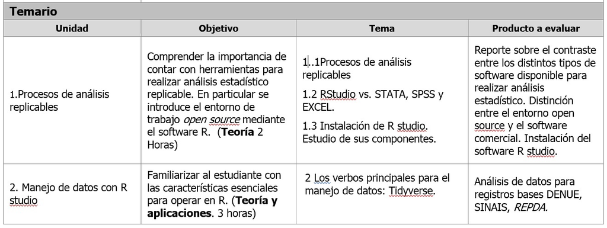

[figure not shown]

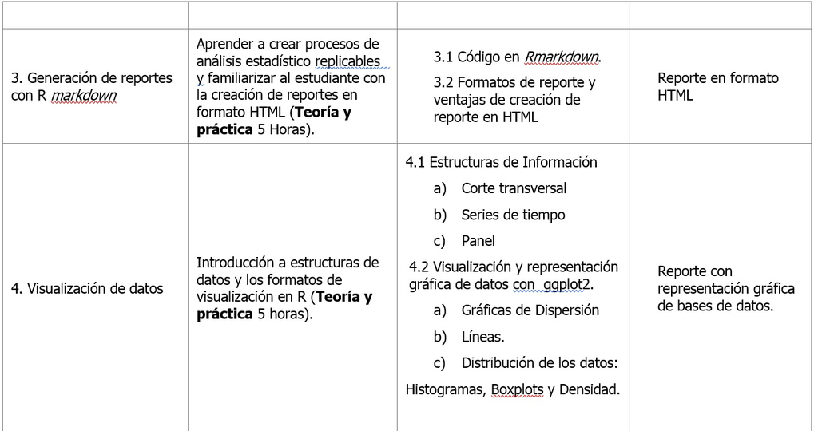

#### Estrategias de aprendizaje utilizadas

Presentación por parte del profesor. Instalación de software open source y colaboración intergrupal con la solución de las asignaciones.

#### Bibliografía

- Peter Dalgaard. Introductory Statistics with R Second Edition. Springer 2008.
- The Art of Data Science A Guide for Anyone Who Works with Data. Roger D. Peng and Elizabeth Matsui. Leanpub.2015.
- Wickham Hadley. Elegant Graphics for Data Analysis, Springer.2009.
- Wilkinson Leland. The Grammar of Graphics, Second Edition. Springer. 2005.
- Report Writing for Data Science in R. Roger D. Peng © 2015 - 2016 Roger D. Peng.

### Software Setup (Installation).

1. On wndows: [download](http://cran.cnr.berkeley.edu/)
2. Mac [download](http://cran.cnr.berkeley.edu/)

R studio

3. Windows and Mac download

[figure not shown]

### A. Nociones Teóricas

#### 1. Procesos de análisis replicables.

¿Qué son los procesos de análisis replicable?

En la realización de análisis estadístico partimos de una pregunta, generalmente un problema que deseamos resolver. Para resolverlo aplicamos una serie de técnicas para analizar información. Dos fases comunes en este proceso son el **Analisis exploratorio de datos y el análisis inferencial**.

Una vez que recorremos este proceso y respondemos el questionamiento inicial, la evidencia aportada con el análisis estadístico involucra el surgimietno de nuevas preguntas.

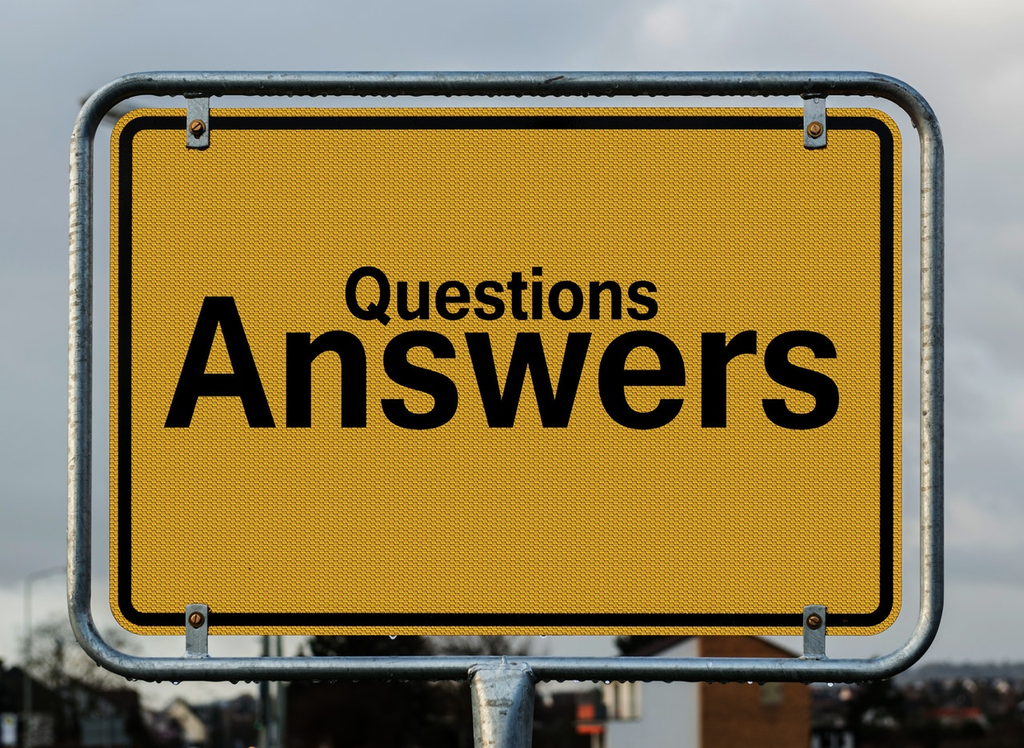

Una característica de este proceso es que es iterativo, es realidad estamos frente a un proceso ciclo. El work flow se repite constantemente.

Sería muy interesante y valioso que los recursos invertidos en términos de tiempo para la solución de un problema pudiesen recurperarse, si, reutilizarse!

[figure not shown]

De esta forma optimizariamos el uso de nuestros recursos.

La forma de hacer este uso óptimo en términos de análisis estadístico de datos es utilizando proceso **replicables**.

Piense en las operaciones que comunmente se hacen en *Excel* por ejemplo. Una vez que se finaliza con una estimación se guarda el archivo y cuando se require hacer un análisis nuevo se abre otro archivo a pesar de que se usan funciones similares para aproximar el cálculo se trabaja doble ya que no se tiene un registro que documente nuestro trabajo paso a paso.

A media que se hacen análisis de mayor complejidad o con un volumen de datos de mayor escala, se hace evidente la necesidad de documentar el proceso de análisis para su repoducción futura.

El entorno de análisis con plataformas como **R studio** esta diseñado explicitamente para permitir la **replicabilidad** del proceso de análisis.

#### 1.2 RStudio vs. STATA, SPSS y EXCEL.

[figure not shown]

La principal ventaja de **R** sobre otros paquetes disponibles en el mercado actualmente es la flexibilidad del entorno *OPEN SOURCE*. Una gran comunidad de usuarios, desarrolla y comparte las herramientas que integran R de foma contínua.

Otra ventajas incluyen:

- Integración de código (lenguaje R).
- Explicitamente incorpora la perspectiva de análisis estadístico y permite la representación gráfica dinámica (ej. Shiny apps).
- Generación de reportes endiversos formatos, como HTML, PDF,etc.No solo word.
- Manejo de grandes volumenes de datos (base de datos que contienen millones de registros (individuos, observaciones…)
- Plataforma que permite utilizar herramientaspara visualización (ej.paquete ggplot2)

#### Ejemplos

Ejemplo 1: **Series de tiempo** facets.

```r
growth<-readRDS("sdr_gr08_16_Edos.rds")%>%
  mutate(fecha=as.numeric(fecha))
glimpse(growth)
```

```
## Rows: 576
## Columns: 8
## $ ENT_NACM <fct> 1, 2, 3, 4, 5, 6, 7, 8, 9, 10, 11, 12, 13, 14, 15, 16, 17,...
## $ sdr      <dbl> 0, 0, 0, 0, 0, 0, 0, 0, 0, 0, 0, 0, 0, 0, 0, 0, 0, 0, 0, 0...
## $ fecha    <dbl> 8, 8, 8, 8, 8, 8, 8, 8, 8, 8, 8, 8, 8, 8, 8, 8, 8, 8, 8, 8...
## $ casos    <int> 22533, 23514, 6693, 13072, 55726, 9557, 76656, 44861, 1934...
## $ logs     <dbl> 10.022736, 10.065351, 8.808817, 9.478228, 10.928202, 9.165...
## $ rate     <dbl> 0, 0, 0, 0, 0, 0, 0, 0, 0, 0, 0, 0, 0, 0, 0, 0, 0, 0, 0, 0...
## $ DESCRIP  <fct> AGS, Baja California, BCS, Campeche, Coahuila , Colima, Ch...
## $ SDR      <chr> "otras", "otras", "otras", "otras", "otras", "otras", "otr...
```

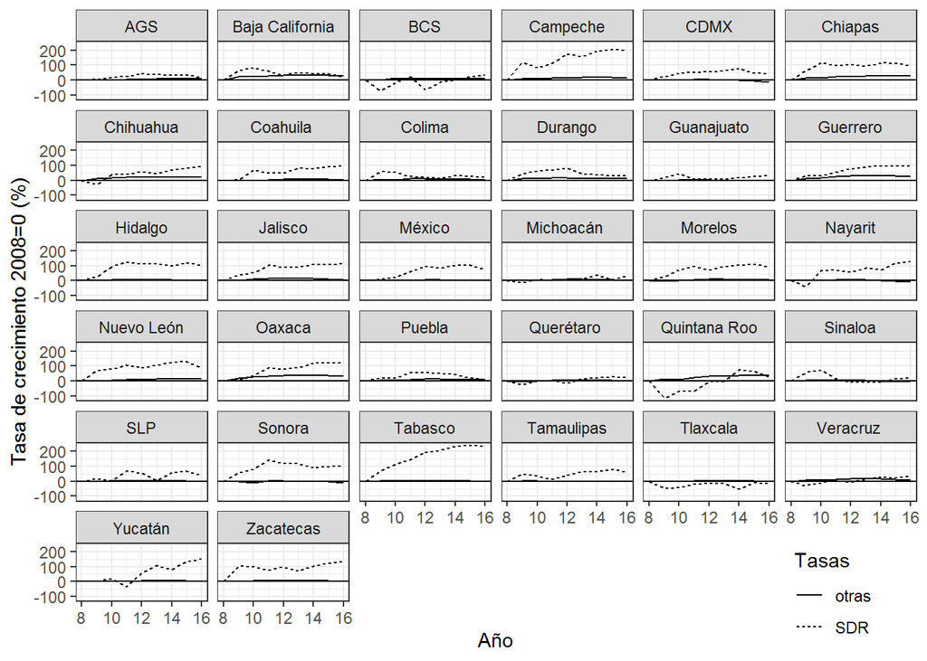

```r
ggplot(growth, aes(x=fecha,  group=SDR, linetype=SDR)) +
  geom_line(aes(y=rate))+
  facet_wrap(~DESCRIP, nrow=6)+
  geom_hline(yintercept = 0)+
  labs(linetype="Tasas")+
  ylab("Tasa de crecimiento 2008=0 (%)") +
  xlab("Año")+
  theme_bw()+theme(legend.position=c(.9,.01))+
  scale_x_continuous(breaks=c(8, 10, 12, 14, 16))
```

**Ejemplo 2:** series de tiempo agrupadas por variable categórica Cociente de localización.

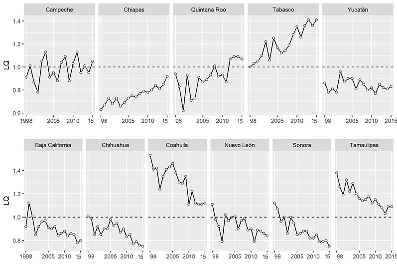

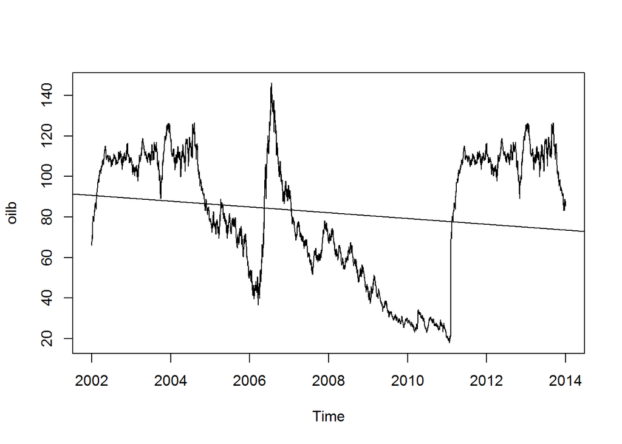

```r
oilbrent<-read.csv("Oil_brent.csv")
oilb<-ts(oilbrent$brentp,start=c(2002),end=c(2014), frequency=365)

plot(oilb)
abline(reg=lm(oilb~time(oilb)))
```

**Ejemplo 4:** time series. Fluctuacione de temperatura. Ej. daily, monthly, year…

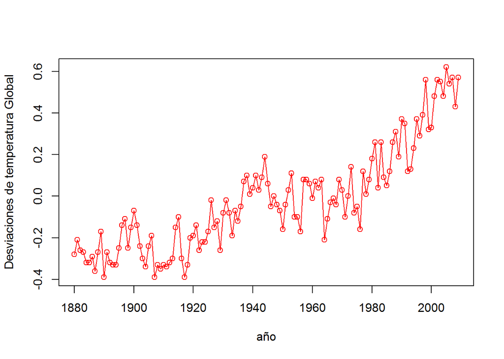

```r
library(astsa)
plot(gtemp, type="o", ylab="Desviaciones de temperatura Global",xlab="año",col="red")
```

**Ejemplo 5:** time series Inflación (INPC BANXICO)

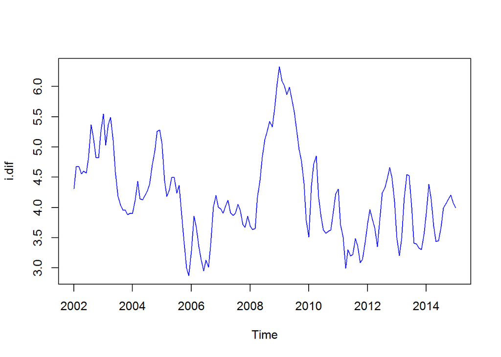

```r
inf<-read.csv("inf14ts.csv")
infts<-ts(inf$SP1,start= c(1982,2),end=c(2015,1),frequency=12)
i.ts<-window(infts,start= c(2001,1), end=c(2015,1))
i.dif<-diff(log(i.ts), lag=12)*100
plot(i.dif,col="blue")
```

```r
View(i.ts)
```

**Ejemplo 6** time series, Desempleo e inflación Mensual (INEGI)

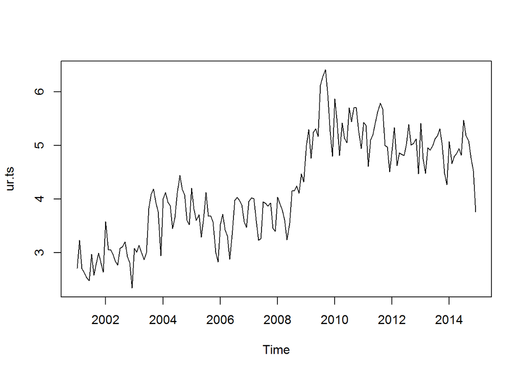

```r
p70<-read.csv("i70inegi.CSV")
i70ts<-ts(p70$inf235830,start= c(1970,1),end=c(2015,1),frequency=12)
i<-window(i70ts,start= c(2001,1), end=c(2015,1))

ur = read.csv("desempmx2001.csv",header = TRUE, stringsAsFactors = FALSE)
ur.ts<-ts(data=ur$ur, frequency = 12, start=c(2001,1),end=c(2014,12))
urinfla.mts = cbind(ur.ts, i)
plot(ur.ts)
```

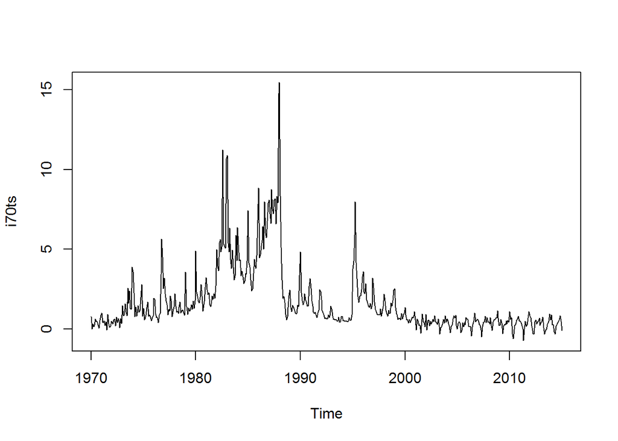

```r
plot(i70ts)
```

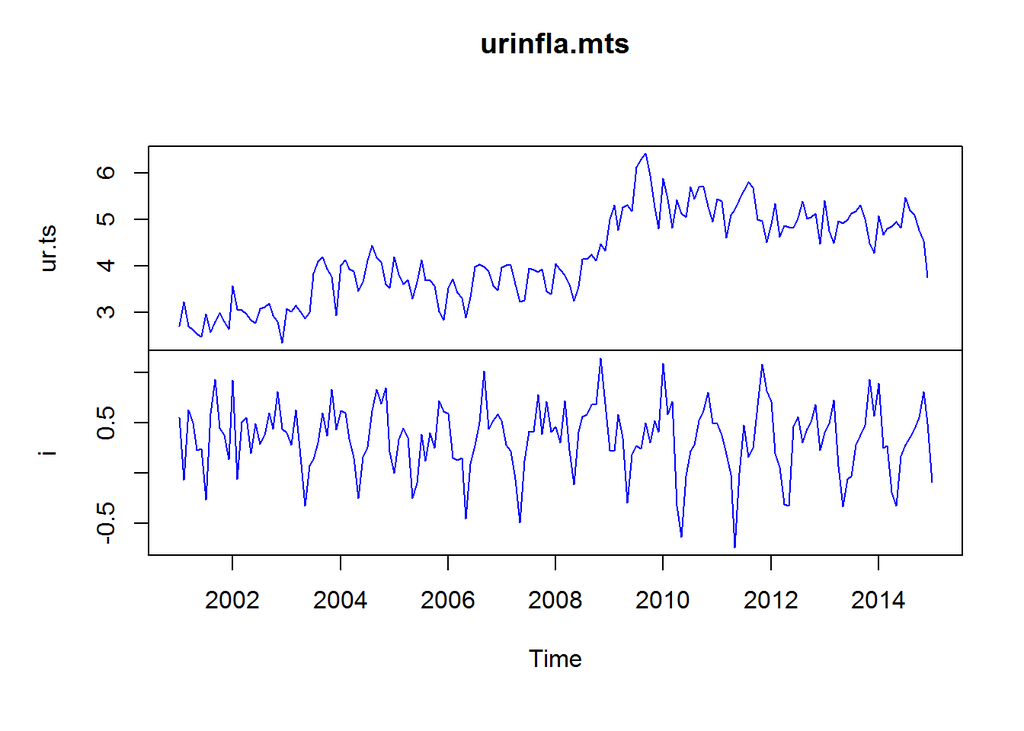

```r
plot(urinfla.mts,col=c("blue", "red"),lty=1:2)
```

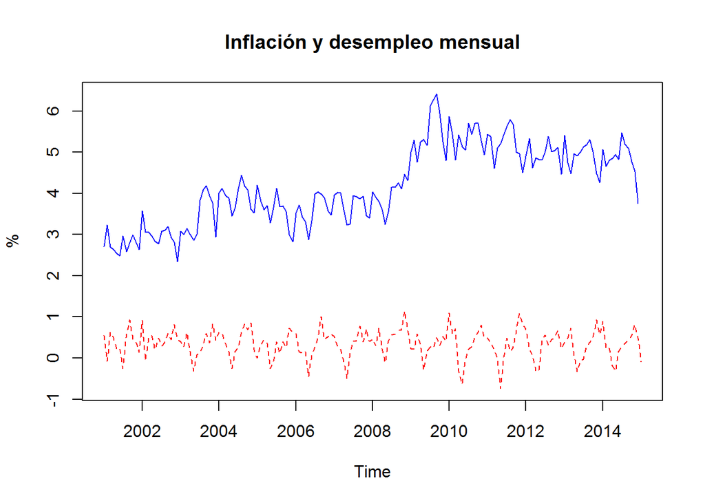

```r
plot(urinfla.mts, plot.type="single", main="Inflación y desempleo mensual",ylab="%",col=c("blue", "red"),lty=1:2)
```

**Ejemplo 7**. Scatter plot, 3 variables: *factors to color and size

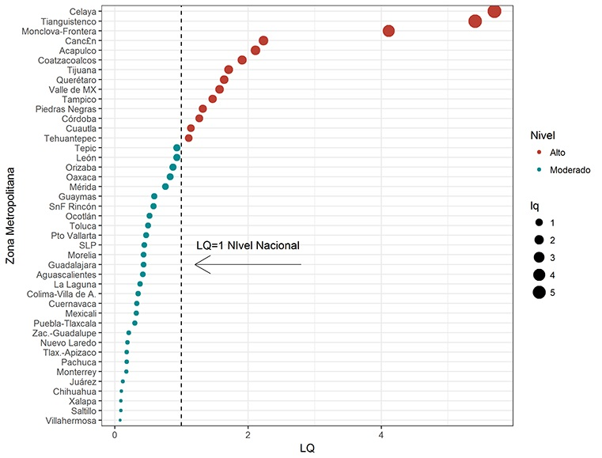

**Ejemplo 8**. Scatter plot Health data, 3 variables: *factors to color and size

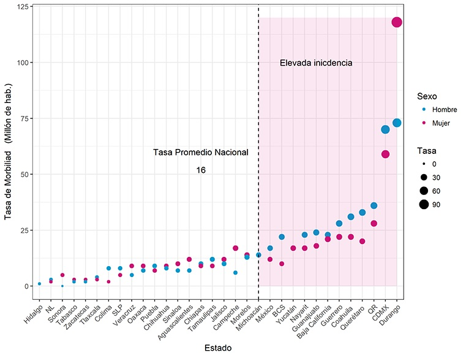

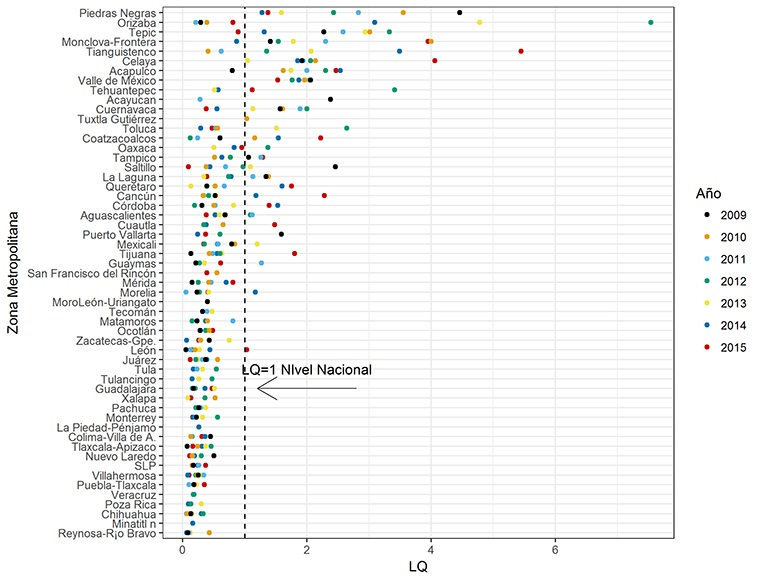

**Ejemplo 10**. Scatter con regression line,

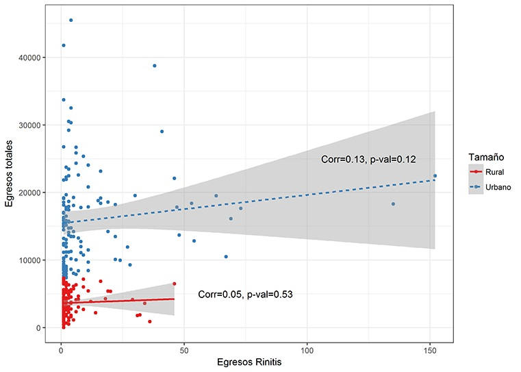

**Ejemplo 11**. Boxplot con variable factorial.

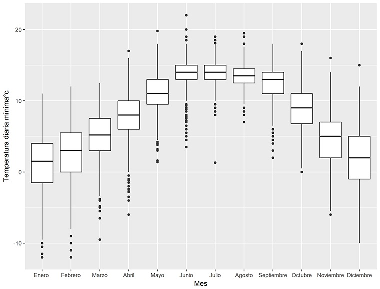

**Asignacion 1** (On class reading): Leer History and Overview of R. Páginas 4 a 10 del libro:

R Programming for Data Science. [Libro](https://www.cs.upc.edu/~robert/teaching/estadistica/rprogramming.pdf)